# Open and Reproducible Research: Tools 1

January 2015

## Topics

- Open and Reproducible
- Rmarkdown
- Sweave (.Rnw)

## F/OSS

- 1980 copyright law was extended to computer programs
- 1985 Free Software Foundation was founded

  Stallman, Richard (1985) "The GNU Manifesto", *Dr. Dobb's Journal* 10(3):30
- 1992 Linux kernel re-licensed under GNU GPL
- 1995 Apache was released under Apache License
- 1998 Open Source Initiative founded; Netscape source was released

  Raymond, Eric (1997) *The Cathedral and the Bazaar*

## Stallman (1985)

- "GNU, which stands for Gnu's Not Unix, is the name for the complete Unix-compatible software system which I am writing so that I can give it away free to everyone who can use it. … Software sellers want to divide the users and conquer them, making each user agree not to share with others. I refuse to break solidarity with other users in this way. I cannot in good conscience sign a nondisclosure agreement or a software license agreement."
- "GNU is not in the public domain. Everyone will be permitted to modify and redistribute GNU, but no distributor will be allowed to restrict its further redistribution. That is to say, proprietary modifications will not be allowed. I want to make sure that all versions of GNU remain free."

## Raymond (1997)

- "Linus Torvalds's style of development – release early and often, delegate everything you can, be open to the point of promiscuity – came as a surprise. No quiet, reverent cathedral-building here – rather, the Linux community seemed to resemble a great babbling bazaar of differing agendas and approaches (aptly symbolized by the Linux archive sites, who'd take submissions from anyone) out of which a coherent and stable system could seemingly emerge only by a succession of miracles."
- "Chance handed me a perfect way to test my theory, in the form of an open-source project that I could consciously try to run in the bazaar style. So I did – and it was a significant success."

## Quiz

Which organization is most closely related to the following quote?

> "free" as in "free speech," not as in "free beer"
1. Open Source Initiative (OSI)
2. International Council for Science (ICSU)
3. Organisation for Economic Co-operation and Development (OECD)
4. Free Software Foundation (FSF)

## Motivation for Reproducibility

"An article about computational science in a scientific publication is *not* the scholarship itself, it is merely *advertising* of the scholarship. The actual scholarship is the complete software development environment and the complete set of instructions which generated the figure."

Buckheit and Donoho (1995)'s distillation of Claerbout and Karrenbach (1992)'s insight

## Replication vs Reproducible Research

- "The ultimate standard for strengthening scientific evidence is *replication* of findings and conducting studies with independent: Investigators, Data, Analytical methods, Laboratories, Instruments."
- "Reproducible Research: Make analytic data and code available so that others may *reproduce* findings."

Peng, Roger. "Reproducible Research: Concepts and Ideas" Lecture note for the Coursera Course titled, *Reproducible Research*. https://github.com/rdpeng/courses/. accessed on 2014-12-24.

## Research Pipeline

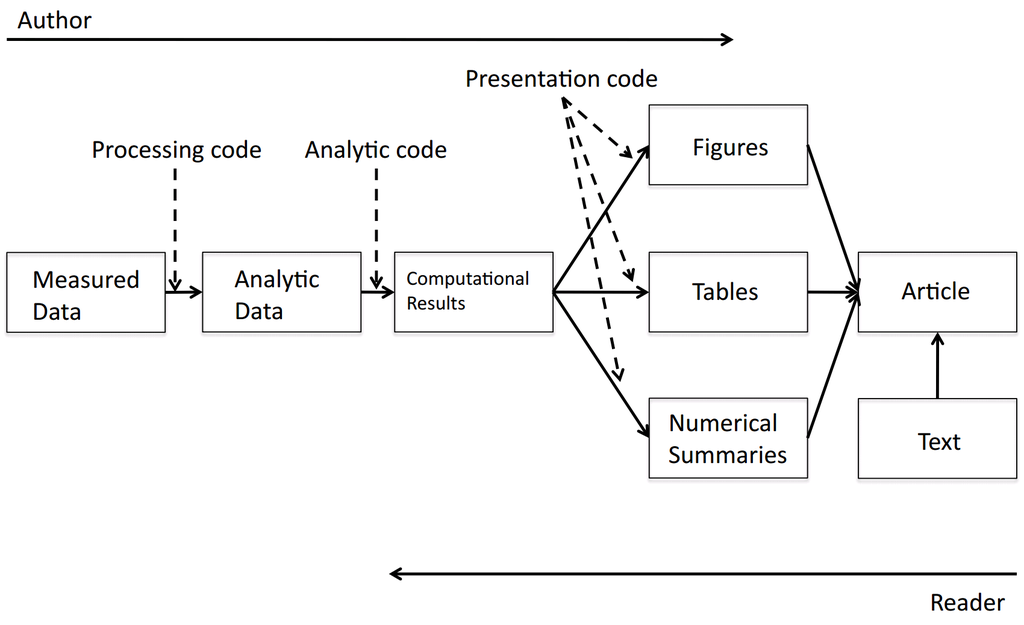

Peng, Roger (2011) "Computational and Policy Tools for Reproducible Research" presentation at *Reproducible Research: Tools and Strategies for Scientific Computing*, a workshop in association with Applied Mathematics Perspectives 2011, University of British Columbia, Vancouver, BC, Canada. July 13-16, 2011. page 6.

## Quiz

Indicate if the following statement is True or False.

1. According to Roger Peng, Replication of the scientific findings by independent investigators using independent methods, data, instruments, and laboratories is the standard method by which scientific findings are verified and is how knowledge is accumulated. (T/F)
2. Replication is always possible. (T/F)
3. In Roger Peng's Research Pipeline, the processing code transforms Measured Data into Analytic Data. (T/F)

## Knuth (1984)

- "I believe that the time is ripe for significantly better documentation of programs, and that we can best achieve this by considering programs to be works of literature. Hence, my title: 'Literate Programming.'"
- "By coining the phrase 'literate programming,' I am imposing a moral commitment on everyone who hears the term; surely nobody wants to admit writing an illiterate program."

Donald E. Knuth. Literate programming. The Computer Journal, 27(2):97-111, May 1984. http://comjnl.oxfordjournals.org/content/27/2/97.full.pdf+html. Accessed on 2014-12-24.